# Bringing It All Together: Complete Economic Analysis

Time to combine everything we've got - FRED economic data, NBER recession dates, and consumer sentiment - into one comprehensive dataset. This is where we'll see the full picture of how different economic signals work together to predict downturns.

```python
# Import notebook utilities
from notebook_utils import init_notebook, load_data, display_data_info, save_figure
import os
import matplotlib.pyplot as plt
from IPython.display import display

# Initialize notebook environment
init_notebook()

# Import from econ_downturn package
from econ_downturn import (
    engineer_features, normalize_data, apply_mda, create_discriminant_time_series,
    plot_indicator_with_recessions, plot_feature_importance,
    plot_discriminant_time_series, plot_sentiment_vs_indicator,
    plot_sentiment_correlation_matrix
)
```

[output not shown]

## Loading All Our Data Sources

Let's pull together data from all our sources - FRED economic indicators, NBER recession dates, and University of Michigan consumer sentiment. This gives us the complete picture.

```python
# Load all data using the utility function
merged_data = load_data(use_cached=False)  # Force reload from original sources

# Display information about the dataset
display_data_info(merged_data)
```

```
Loading data from original sources...
2025-06-12 13:16:13,415 - econ_downturn.data.data_loader - INFO - Loaded FRED data with shape: (15510, 10)
2025-06-12 13:16:13,417 - econ_downturn.data.data_loader - INFO - Loaded NBER recession data with shape: (653, 1)
2025-06-12 13:16:13,419 - econ_downturn.data.data_loader - INFO - Loaded UMich data with shape: (653, 2)
2025-06-12 13:16:13,420 - econ_downturn.data.data_loader - INFO - Initialized merged dataset with 'FRED' data
2025-06-12 13:16:13,426 - econ_downturn.data.data_loader - INFO - Added 'NBER' data to merged dataset
2025-06-12 13:16:13,428 - econ_downturn.data.data_loader - INFO - Added 'UMICH' data to merged dataset
2025-06-12 13:16:13,428 - econ_downturn.data.data_loader - INFO - Merged dataset shape: (15657, 13)
2025-06-12 13:16:13,468 - econ_downturn.data.data_loader - INFO - Saved merged dataset to /home/mattgroho/github/economic-downturn-detector/data/processed/merged_data.csv
Loaded and merged data with shape: (15657, 13)
Dataset Information:
Time Range: 1970-01-01 00:00:00 to 2024-05-31 00:00:00
Number of Observations: 15657
Number of Features: 13

Summary Statistics:
```

|  | GDP | UNEMPLOYMENT | CPI | FED_FUNDS | YIELD_CURVE | INITIAL_CLAIMS | INDUSTRIAL_PROD | RETAIL_SALES | HOUSING_STARTS | CONSUMER_SENTIMENT | recession | SENTIMENT | INFLATION_EXPECTATION |
| --- | --- | --- | --- | --- | --- | --- | --- | --- | --- | --- | --- | --- | --- |
| count | 218.000000 | 653.000000 | 653.000000 | 653.000000 | 11998.000000 | 2.839000e+03 | 653.000000 | 389.000000 | 653.000000 | 589.000000 | 653.000000 | 589.000000 | 557.000000 |
| mean | 12837.776711 | 6.110260 | 158.663954 | 4.910490 | 0.868401 | 3.733381e+05 | 74.982246 | 365236.395887 | 1435.917305 | 84.583531 | 0.128637 | 84.583531 | 3.590126 |
| std | 5217.489014 | 1.709394 | 73.783619 | 3.898737 | 0.925610 | 2.450608e+05 | 22.585732 | 138186.138422 | 410.165486 | 13.111529 | 0.335054 | 13.111529 | 1.625392 |
| min | 5299.672000 | 3.400000 | 37.900000 | 0.050000 | -2.410000 | 1.890000e+05 | 36.388100 | 158647.000000 | 478.000000 | 50.000000 | 0.000000 | 50.000000 | 0.400000 |
| 25% | 7760.008000 | 4.900000 | 100.100000 | 1.510000 | 0.190000 | 3.010000e+05 | 51.806000 | 264067.000000 | 1176.000000 | 74.300000 | 0.000000 | 74.300000 | 2.800000 |
| 50% | 12216.346500 | 5.800000 | 159.800000 | 5.050000 | 0.830000 | 3.460000e+05 | 78.919700 | 349869.000000 | 1465.000000 | 88.200000 | 0.000000 | 88.200000 | 3.000000 |
| 75% | 16937.626250 | 7.200000 | 219.035000 | 6.890000 | 1.500000 | 4.020000e+05 | 97.606000 | 443117.000000 | 1698.000000 | 94.200000 | 0.000000 | 94.200000 | 3.500000 |
| max | 23223.906000 | 14.800000 | 313.140000 | 19.100000 | 2.910000 | 6.137000e+06 | 104.103800 | 691223.000000 | 2494.000000 | 112.000000 | 1.000000 | 112.000000 | 10.400000 |

```
Missing Values:
```

|  | Missing Values | Percentage |
| --- | --- | --- |
| GDP | 15439 | 98.607652 |
| RETAIL_SALES | 15268 | 97.515488 |
| INFLATION_EXPECTATION | 15100 | 96.442486 |
| CONSUMER_SENTIMENT | 15068 | 96.238104 |
| SENTIMENT | 15068 | 96.238104 |
| UNEMPLOYMENT | 15004 | 95.829342 |
| CPI | 15004 | 95.829342 |
| FED_FUNDS | 15004 | 95.829342 |
| INDUSTRIAL_PROD | 15004 | 95.829342 |
| HOUSING_STARTS | 15004 | 95.829342 |
| recession | 15004 | 95.829342 |
| INITIAL_CLAIMS | 12818 | 81.867535 |
| YIELD_CURVE | 3659 | 23.369739 |

## Exploring Consumer Sentiment Patterns

Now let's see how consumer sentiment behaves around recessions. Does it drop before economic downturns? How does it relate to other indicators like unemployment and GDP?

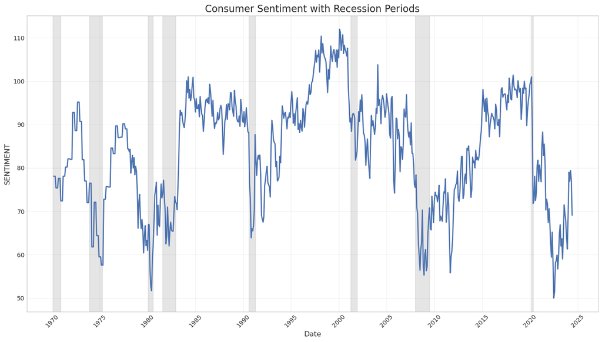

```
Saved figure to /home/mattgroho/github/economic-downturn-detector/docs/images/consumer_sentiment.png
```

```python
# Plot consumer sentiment over time with recession periods
fig = plot_indicator_with_recessions(
    merged_data,
    'SENTIMENT',
    title='Consumer Sentiment with Recession Periods'
)
plt.show()
save_figure(fig, "consumer_sentiment.png")
```

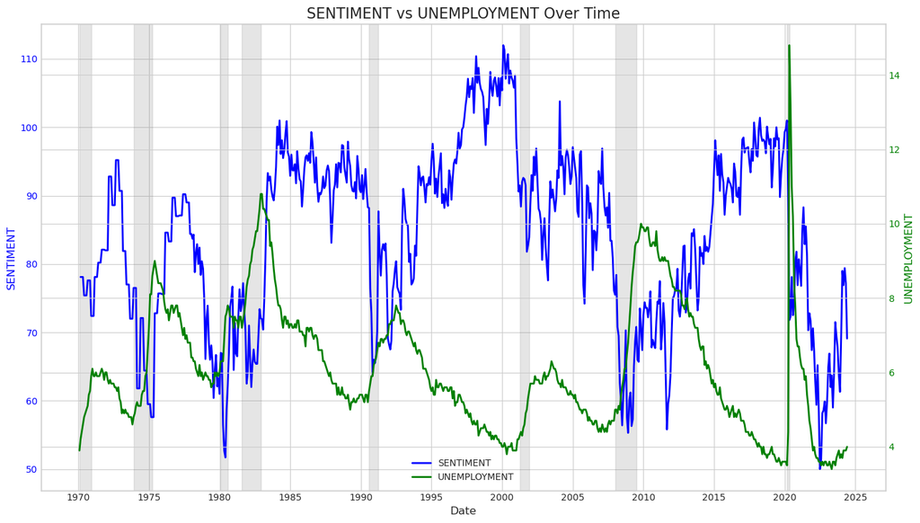

```
Saved figure to /home/mattgroho/github/economic-downturn-detector/docs/images/sentiment_vs_unemployment.png
```

```python
# Plot consumer sentiment vs unemployment rate
fig = plot_sentiment_vs_indicator(
    merged_data,
    sentiment_col='SENTIMENT',
    indicator_col='UNEMPLOYMENT'
)
plt.show()
save_figure(fig, "sentiment_vs_unemployment.png")
```

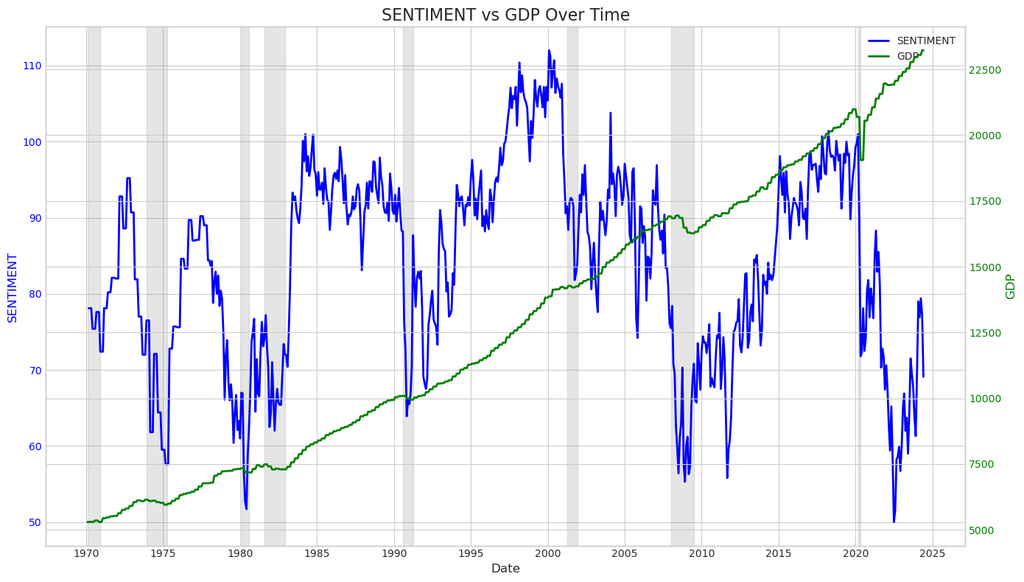

```
Saved figure to /home/mattgroho/github/economic-downturn-detector/docs/images/sentiment_vs_gdp.png
```

```python
# Plot consumer sentiment vs GDP growth
fig = plot_sentiment_vs_indicator(
    merged_data,
    sentiment_col='SENTIMENT',
    indicator_col='GDP'
)
plt.show()
save_figure(fig, "sentiment_vs_gdp.png")
```

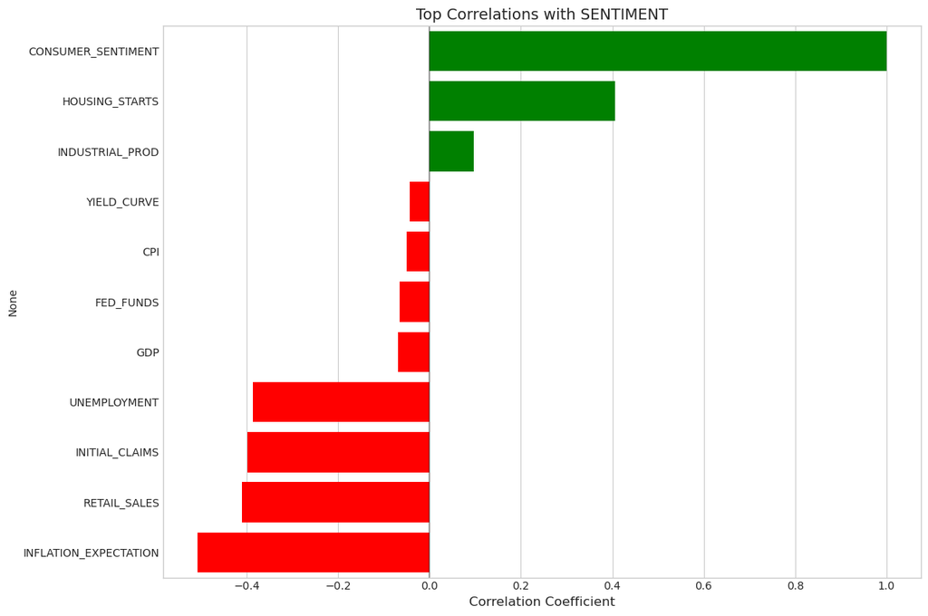

```
Saved figure to /home/mattgroho/github/economic-downturn-detector/docs/images/sentiment_correlation_matrix.png
```

```python
# Plot correlations between consumer sentiment and economic indicators
fig = plot_sentiment_correlation_matrix(
    merged_data,
    sentiment_cols=['SENTIMENT'],
    top_n=10
)
plt.show()
save_figure(fig, "sentiment_correlation_matrix.png")
```

## Engineering Features with Sentiment Data

Time to create some smart features using our combined dataset. We'll build lag variables and transformations that capture how sentiment and economic indicators interact over time.

```python
# Handle missing values and create lag variables
data_with_features = engineer_features(merged_data)

print(f"Data with features shape: {data_with_features.shape}")
print(f"Number of features: {data_with_features.shape[1]}")

# Save the dataset with features
from econ_downturn import get_data_paths
data_paths = get_data_paths()
output_dir = data_paths['processed_dir']
os.makedirs(output_dir, exist_ok=True)
features_path = os.path.join(output_dir, 'data_with_features_and_sentiment.csv')
data_with_features.to_csv(features_path)
print(f"Saved dataset with features to {features_path}")
```

```
2025-06-12 13:16:14,708 - econ_downturn.features.feature_engineering - WARNING - There are still 15004 missing values after handling
2025-06-12 13:16:14,712 - econ_downturn.features.feature_engineering - INFO - Resampled data to M frequency, new shape: (653, 13)
2025-06-12 13:16:14,712 - econ_downturn.features.feature_engineering - INFO - Resampled data to M frequency, new shape: (653, 13)
2025-06-12 13:16:14,718 - econ_downturn.features.feature_engineering - INFO - Created lag variables with periods [1, 3, 6, 12], new shape: (653, 61)
2025-06-12 13:16:14,734 - econ_downturn.features.feature_engineering - INFO - Calculated rate of change with periods [1, 3, 12], new shape: (653, 97)
2025-06-12 13:16:14,736 - econ_downturn.features.feature_engineering - INFO - Dropped rows with missing values, new shape: (635, 97)
2025-06-12 13:16:14,737 - econ_downturn.features.feature_engineering - INFO - Completed feature engineering, final shape: (635, 97)
Data with features shape: (635, 97)
Number of features: 97
Saved dataset with features to /home/mattgroho/github/economic-downturn-detector/data/processed/data_with_features_and_sentiment.csv
```

## Normalizing for Fair Comparison

Different indicators have different scales, so let's normalize everything to ensure our model treats all features equally.

```python
# Normalize the data
data_normalized, scaler = normalize_data(data_with_features)

print(f"Normalized data shape: {data_normalized.shape}")

# Save the normalized dataset
normalized_path = os.path.join(output_dir, 'data_normalized_with_sentiment.csv')
data_normalized.to_csv(normalized_path)
print(f"Saved normalized dataset to {normalized_path}")
```

```
2025-06-12 13:16:14,778 - econ_downturn.features.normalization - INFO - Normalized data using standard method, shape: (635, 97)
Normalized data shape: (635, 97)
Saved normalized dataset to /home/mattgroho/github/economic-downturn-detector/data/processed/data_normalized_with_sentiment.csv
```

## Testing Our Enhanced Model

```python
# Separate features and target
X = data_normalized.drop(columns=['recession'])
y = data_normalized['recession']

# Apply MDA
mda_results = apply_mda(X, y)

# Print model performance metrics
print(f"Accuracy: {mda_results['accuracy']:.4f}")
print("\nConfusion Matrix:")
print(mda_results['conf_matrix'])
print("\nClassification Report:")
print(mda_results['class_report'])
print(f"\nCross-Validation Scores: {mda_results['cv_scores']}")
print(f"Mean CV Score: {mda_results['cv_scores'].mean():.4f}")
```

```
2025-06-12 13:16:14,830 - econ_downturn.models.mda - INFO - Training set shape: (444, 96), Testing set shape: (191, 96)
2025-06-12 13:16:14,847 - econ_downturn.models.mda - INFO - Accuracy: 0.9581
2025-06-12 13:16:14,848 - econ_downturn.models.mda - INFO - Confusion Matrix:
[[165   4]
 [  4  18]]
2025-06-12 13:16:14,850 - econ_downturn.models.mda - INFO - Classification Report:
              precision    recall  f1-score   support

         0.0       0.98      0.98      0.98       169
         1.0       0.82      0.82      0.82        22

    accuracy                           0.96       191
   macro avg       0.90      0.90      0.90       191
weighted avg       0.96      0.96      0.96       191

2025-06-12 13:16:14,880 - econ_downturn.models.mda - INFO - Cross-Validation Scores: [0.96062992 0.96850394 0.96850394 0.93700787 0.99212598]
2025-06-12 13:16:14,881 - econ_downturn.models.mda - INFO - Mean CV Score: 0.9654
2025-06-12 13:16:14,882 - econ_downturn.models.mda - INFO - Top 5 Most Important Features:
                 Feature  Importance
2                    CPI  309.869511
20              CPI_lag1  243.170068
13              GDP_lag3  241.123560
36  INDUSTRIAL_PROD_lag1  232.499571
15             GDP_lag12  174.900665
Accuracy: 0.9581

Confusion Matrix:
[[165   4]
 [  4  18]]

Classification Report:
              precision    recall  f1-score   support

         0.0       0.98      0.98      0.98       169
         1.0       0.82      0.82      0.82        22

    accuracy                           0.96       191
   macro avg       0.90      0.90      0.90       191
weighted avg       0.96      0.96      0.96       191


Cross-Validation Scores: [0.96062992 0.96850394 0.96850394 0.93700787 0.99212598]
Mean CV Score: 0.9654
```

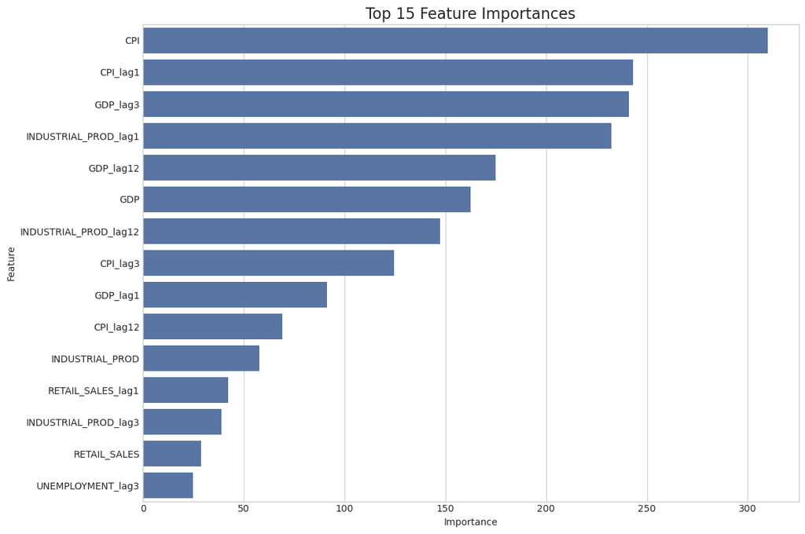

```
Saved figure to /home/mattgroho/github/economic-downturn-detector/docs/images/feature_importance_with_sentiment.png
```

```python
# Plot feature importances
if mda_results['feature_importance'] is not None:
    fig = plot_feature_importance(mda_results['feature_importance'])
    plt.show()
    save_figure(fig, "feature_importance_with_sentiment.png")
```

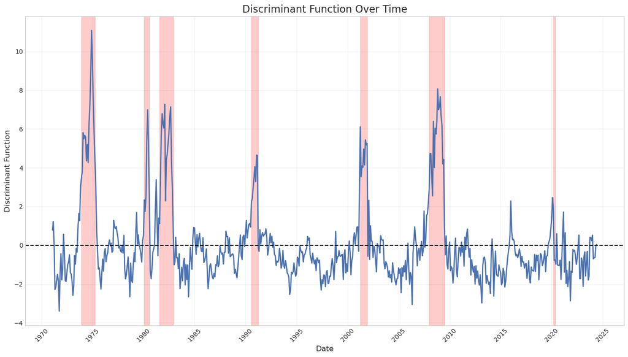

```
Saved figure to /home/mattgroho/github/economic-downturn-detector/docs/images/discriminant_time_series_with_sentiment.png
```

```python
# Create and plot discriminant time series
discriminant_df = create_discriminant_time_series(
    mda_results['model'], X, y
)

fig = plot_discriminant_time_series(discriminant_df)
plt.show()
save_figure(fig, "discriminant_time_series_with_sentiment.png")
```